# Diabetes EDA

```python
# Setup
import warnings
import pandas as pd
import numpy as np
import seaborn as sns
import matplotlib.pyplot as plt

warnings.filterwarnings('ignore', category=FutureWarning)

sns.set_theme(style="whitegrid")
df = pd.read_csv('diabetes_health_indicators.csv')
```

```python
# Check for any missing values (NA/NaN)
missing_counts = df.isnull().sum()
total_rows = len(df)
missing_percentages = (missing_counts / total_rows) * 100

print(f"\nMissing values: {missing_counts}")
print(f"\nMissing percentages: {missing_percentages}")
```

```
Missing values: Diabetes_012            0
HighBP                  0
HighChol                0
CholCheck               0
BMI                     0
Smoker                  0
Stroke                  0
HeartDiseaseorAttack    0
PhysActivity            0
Fruits                  0
Veggies                 0
HvyAlcoholConsump       0
AnyHealthcare           0
NoDocbcCost             0
GenHlth                 0
MentHlth                0
PhysHlth                0
DiffWalk                0
Sex                     0
Age                     0
Education               0
Income                  0
dtype: int64

Missing percentages: Diabetes_012            0.0
HighBP                  0.0
HighChol                0.0
CholCheck               0.0
BMI                     0.0
Smoker                  0.0
Stroke                  0.0
HeartDiseaseorAttack    0.0
PhysActivity            0.0
Fruits                  0.0
Veggies                 0.0
HvyAlcoholConsump       0.0
AnyHealthcare           0.0
NoDocbcCost             0.0
GenHlth                 0.0
MentHlth                0.0
PhysHlth                0.0
DiffWalk                0.0
Sex                     0.0
Age                     0.0
Education               0.0
Income                  0.0
dtype: float64
```

```python
# Convert all floats to ints
for name, values in df.items():
    if name in df.columns:
        df[name] = pd.to_numeric(df[name], errors='coerce')
        df[name] = df[name].astype('Int64')

df.head()
```

|  | Diabetes_012 | HighBP | HighChol | CholCheck | BMI | Smoker | Stroke | HeartDiseaseorAttack | PhysActivity | Fruits | ... | AnyHealthcare | NoDocbcCost | GenHlth | MentHlth | PhysHlth | DiffWalk | Sex | Age | Education | Income |
| --- | --- | --- | --- | --- | --- | --- | --- | --- | --- | --- | --- | --- | --- | --- | --- | --- | --- | --- | --- | --- | --- |
| 0 | 0 | 1 | 1 | 1 | 40 | 1 | 0 | 0 | 0 | 0 | ... | 1 | 0 | 5 | 18 | 15 | 1 | 0 | 9 | 4 | 3 |
| 1 | 0 | 0 | 0 | 0 | 25 | 1 | 0 | 0 | 1 | 0 | ... | 0 | 1 | 3 | 0 | 0 | 0 | 0 | 7 | 6 | 1 |
| 2 | 0 | 1 | 1 | 1 | 28 | 0 | 0 | 0 | 0 | 1 | ... | 1 | 1 | 5 | 30 | 30 | 1 | 0 | 9 | 4 | 8 |
| 3 | 0 | 1 | 0 | 1 | 27 | 0 | 0 | 0 | 1 | 1 | ... | 1 | 0 | 2 | 0 | 0 | 0 | 0 | 11 | 3 | 6 |
| 4 | 0 | 1 | 1 | 1 | 24 | 0 | 0 | 0 | 1 | 1 | ... | 1 | 0 | 2 | 3 | 0 | 0 | 0 | 11 | 5 | 4 |

5 rows × 22 columns

```python
# Map numerical data to descriptive data
# Create copy for cleaning
df = df.rename(columns={'Diabetes_012': 'Diabetes_Status'})
df_clean = df.copy()

binary_map = {0: 'No', 1: 'Yes', 7: 'Not Sure', 9: 'No Response'}
sex_map = {0: 'Female', 1: 'Male'}

diabetes_map = {
    0: 'No Diabetes',
    1: 'Prediabetes',
    2: 'Diabetes'
}

gen_hlth_map = {
    1: 'Excellent',
    2: 'Very Good',
    3: 'Good',
    4: 'Fair',
    5: 'Poor',
    7: 'Not Sure',
    9: 'No Response'
}

education_map = {
    1: 'Never attended school',
    2: 'Grades 1-8',
    3: 'Grades 9-11',
    4: 'Grade 12/GED',
    5: 'College 1-3 years',
    6: 'College 4+ years',
    9: 'No Response',
}

income_map = {
    1: '< $10,000',
    2: '$10,000 - $14,999',
    3: '$15,000 - $19,999',
    4: '$20,000 - $24,999',
    5: '$25,000 - $34,999',
    6: '$35,000 - $49,999',
    7: '$50,000 - $74,999',
    8: '>= $75,000',
    77: 'Not Sure',
    99: 'No Response'
}

age_map = {
    1: '18-24', 2: '25-29', 3: '30-34', 4: '35-39', 5: '40-44',
    6: '45-49', 7: '50-54', 8: '55-59', 9: '60-64', 10: '65-69',
    11: '70-74', 12: '75-79', 13: '80+', 14: 'No Response'
}


df_clean['Diabetes_Status'] = df_clean['Diabetes_Status'].map(diabetes_map)

binary_cols = [
    'HighBP', 'HighChol', 'CholCheck', 'Smoker', 'Stroke',
    'HeartDiseaseorAttack', 'PhysActivity', 'Fruits', 'Veggies',
    'HvyAlcoholConsump', 'AnyHealthcare', 'NoDocbcCost', 'DiffWalk'
]

for col in binary_cols:
    if col in df.columns:
        df_clean[col] = df_clean[col].map(binary_map)


df_clean['Sex'] = df_clean['Sex'].map(sex_map)

scale_mappings = {
    'GenHlth': gen_hlth_map,
    'Education': education_map,
    'Income': income_map,
    'Age': age_map
}

for col, mapping in scale_mappings.items():
    if col in df.columns:
        df_clean[col] = df_clean[col].map(mapping)

df_clean.head()
```

|  | Diabetes_Status | HighBP | HighChol | CholCheck | BMI | Smoker | Stroke | HeartDiseaseorAttack | PhysActivity | Fruits | ... | AnyHealthcare | NoDocbcCost | GenHlth | MentHlth | PhysHlth | DiffWalk | Sex | Age | Education | Income |
| --- | --- | --- | --- | --- | --- | --- | --- | --- | --- | --- | --- | --- | --- | --- | --- | --- | --- | --- | --- | --- | --- |
| 0 | No Diabetes | Yes | Yes | Yes | 40 | Yes | No | No | No | No | ... | Yes | No | Poor | 18 | 15 | Yes | Female | 60-64 | Grade 12/GED | $15,000 - $19,999 |
| 1 | No Diabetes | No | No | No | 25 | Yes | No | No | Yes | No | ... | No | Yes | Good | 0 | 0 | No | Female | 50-54 | College 4+ years | < $10,000 |
| 2 | No Diabetes | Yes | Yes | Yes | 28 | No | No | No | No | Yes | ... | Yes | Yes | Poor | 30 | 30 | Yes | Female | 60-64 | Grade 12/GED | >= $75,000 |
| 3 | No Diabetes | Yes | No | Yes | 27 | No | No | No | Yes | Yes | ... | Yes | No | Very Good | 0 | 0 | No | Female | 70-74 | Grades 9-11 | $35,000 - $49,999 |
| 4 | No Diabetes | Yes | Yes | Yes | 24 | No | No | No | Yes | Yes | ... | Yes | No | Very Good | 3 | 0 | No | Female | 70-74 | College 1-3 years | $20,000 - $24,999 |

5 rows × 22 columns

# Diabetes Health Indicators Analysis

## Background

Diabetes is a chronic health condition affecting millions of people worldwide. This project analyzes a dataset of health indicators to understand factors associated with diabetes prevalence and risk.

## Problem Definition

This analysis aims to:

1. Identify which health indicators are most strongly associated with diabetes status
2. Examine how demographic factors correlate with diabetes risk
3. Explore relationships between modifiable risk factors and diabetes
4. Suggest potential intervention points for diabetes prevention

```python
# Basic dataset statistics
print("Dataset overview:")
print(f"Total records: {len(df_clean)}")
print(f"Features: {df_clean.shape[1]}")

# Distribution of diabetes status
diabetes_counts = df_clean['Diabetes_Status'].value_counts()
print(f"\nDistribution of diabetes status:\n{diabetes_counts}")
print(f"Percentage:\n{round(diabetes_counts / len(df_clean) * 100, 2)}%")

# Analyze key health indicators by diabetes status
print("\n--- Key Health Indicators by Diabetes Status ---")
for column in ['HighBP', 'HighChol', 'BMI', 'GenHlth', 'Age']:
    print(f"\n{column} by Diabetes Status:")
    cross_tab = pd.crosstab(df_clean['Diabetes_Status'], df_clean[column])
    percentage = pd.crosstab(df_clean['Diabetes_Status'], df_clean[column],
                            normalize='index').round(3) * 100
    print(f"Counts:\n{cross_tab}")
    print(f"Percentage:\n{percentage}")

# Analyze demographic factors
print("\n--- Demographic Analysis ---")
for column in ['Sex', 'Age', 'Education', 'Income']:
    print(f"\nDiabetes Status by {column}:")
    demo_cross = pd.crosstab(df_clean[column], df_clean['Diabetes_Status'],
                            normalize='index').round(3) * 100
    print(demo_cross)

# Summary statistics by diabetes status
print("\n--- Summary Statistics by Diabetes Status ---")
numeric_cols = ['BMI', 'PhysHlth', 'MentHlth']
for status in df_clean['Diabetes_Status'].unique():
    subset = df[df_clean['Diabetes_Status'] == status]
    print(f"\nFor {status}:")
    print(subset[numeric_cols].describe().round(2))
```

```
Dataset overview:
Total records: 253680
Features: 22

Distribution of diabetes status:
Diabetes_Status
No Diabetes    213703
Diabetes        35346
Prediabetes      4631
Name: count, dtype: int64
Percentage:
Diabetes_Status
No Diabetes    84.24
Diabetes       13.93
Prediabetes     1.83
Name: count, dtype: float64%

--- Key Health Indicators by Diabetes Status ---

HighBP by Diabetes Status:
Counts:
HighBP               No    Yes
Diabetes_Status
Diabetes           8742  26604
No Diabetes      134391  79312
Prediabetes        1718   2913
Percentage:
HighBP             No   Yes
Diabetes_Status
Diabetes         24.7  75.3
No Diabetes      62.9  37.1
Prediabetes      37.1  62.9

HighChol by Diabetes Status:
Counts:
HighChol             No    Yes
Diabetes_Status
Diabetes          11660  23686
No Diabetes      132673  81030
Prediabetes        1756   2875
```

[output cut: 143 more lines]

```
25%       27.0       0.0       0.0
50%       31.0       1.0       0.0
75%       35.0      15.0       3.0
max       98.0      30.0      30.0

For Prediabetes:
          BMI  PhysHlth  MentHlth
count  4631.0    4631.0    4631.0
mean    30.72      6.35      4.53
std      6.96      10.3       8.9
min      13.0       0.0       0.0
25%      26.0       0.0       0.0
50%      30.0       0.0       0.0
75%      34.0       8.0       4.0
max      96.0      30.0      30.0
```

The dataset reveals a significant disparity in diabetes prevalence among the studied population. The majority of subjects (approximately 85%) have no diabetes, while only about 13% have diabetes and a mere 2% have prediabetes. This distribution highlights that while diabetes affects a minority of the population, it still represents a substantial health burden given the sample size. The stark contrast between these groups provides a strong basis for comparative analysis of risk factors and demographic patterns associated with the condition.

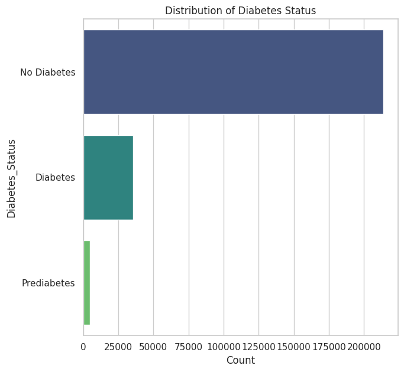

```python
# Create a dashboard of visualizations
plt.figure(figsize=(18, 12))

# Diabetes Status Distribution
plt.subplot(2, 3, 1)
sns.countplot(y='Diabetes_Status', data=df_clean, palette='viridis')
plt.title('Distribution of Diabetes Status')
plt.xlabel('Count')
plt.tight_layout()
```

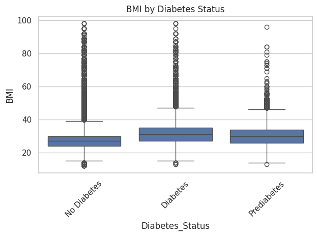

```python
# BMI vs Diabetes Status
sns.boxplot(x='Diabetes_Status', y='BMI', data=df_clean)
plt.title('BMI by Diabetes Status')
plt.xticks(rotation=45)
plt.tight_layout()
```

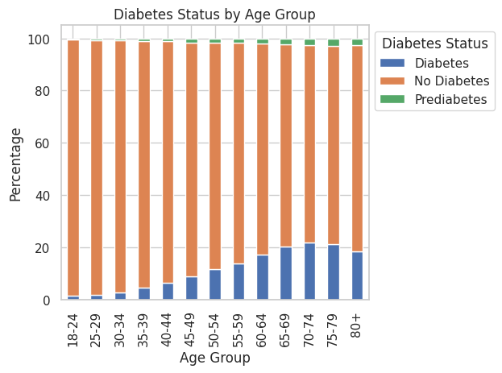

```python
# Age Distribution by Diabetes
age_diabetes = pd.crosstab(df_clean['Age'], df_clean['Diabetes_Status'], normalize='index') * 100
age_diabetes.plot(kind='bar', stacked=True)
plt.title('Diabetes Status by Age Group')
plt.xlabel('Age Group')
plt.ylabel('Percentage')
plt.xticks(rotation=90)
plt.legend(title='Diabetes Status', loc='upper left', bbox_to_anchor=(1, 1))
plt.tight_layout()
```

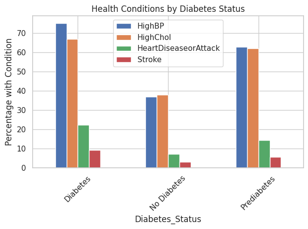

```python
# Health Metrics Comparison
health_vars = ['HighBP', 'HighChol', 'HeartDiseaseorAttack', 'Stroke']
yes_percentages = {}

for var in health_vars:
    yes_percentages[var] = pd.crosstab(df_clean['Diabetes_Status'], df_clean[var])['Yes'] / \
                         df_clean['Diabetes_Status'].value_counts() * 100

pd.DataFrame(yes_percentages).plot(kind='bar')
plt.title('Health Conditions by Diabetes Status')
plt.ylabel('Percentage with Condition')
plt.xticks(rotation=45)
plt.tight_layout()
```

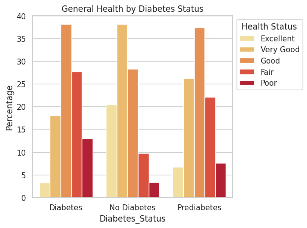

```python
# General Health by Diabetes
health_order = ['Excellent', 'Very Good', 'Good', 'Fair', 'Poor']
gen_health = pd.crosstab(df_clean['Diabetes_Status'], df_clean['GenHlth'])
gen_health_pct = gen_health.div(gen_health.sum(axis=1), axis=0) * 100

# Select only the ordered health categories and convert to DataFrame for plotting
gen_health_pct_ordered = gen_health_pct[health_order].reset_index()
gen_health_pct_ordered = pd.melt(gen_health_pct_ordered, id_vars=['Diabetes_Status'],
                                value_vars=health_order)

sns.barplot(x='Diabetes_Status', y='value', hue='GenHlth', data=gen_health_pct_ordered,
           hue_order=health_order, palette='YlOrRd')
plt.title('General Health by Diabetes Status')
plt.ylabel('Percentage')
plt.legend(title='Health Status', loc='upper left', bbox_to_anchor=(1, 1))
plt.tight_layout()
```

The analysis of lifestyle behaviors in the bar chart below reveals meaningful differences across diabetes status groups. People without diabetes show higher rates of positive health behaviors: physical activity (78%), fruit consumption (63%), and vegetable intake (81%) compared to diabetic individuals (63%, 60%, and 75% respectively). Heavy alcohol consumption is generally low across all groups but slightly higher in those without diabetes. These patterns suggest that lifestyle modifications might be both preventive for those at risk and therapeutic for those already diagnosed with diabetes or prediabetes, with particular emphasis on increasing physical activity.

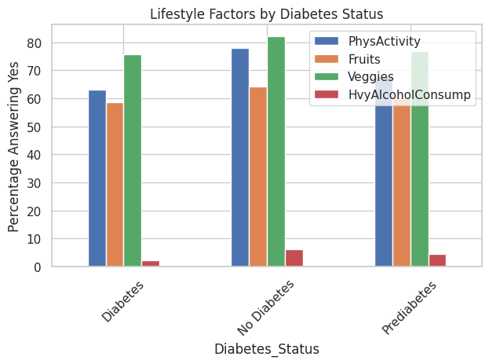

```python
# Lifestyle Factors
lifestyle = ['PhysActivity', 'Fruits', 'Veggies', 'HvyAlcoholConsump']
lifestyle_yes = {}

for var in lifestyle:
    lifestyle_yes[var] = pd.crosstab(df_clean['Diabetes_Status'], df_clean[var])['Yes'] / \
                        df_clean['Diabetes_Status'].value_counts() * 100

pd.DataFrame(lifestyle_yes).plot(kind='bar')
plt.title('Lifestyle Factors by Diabetes Status')
plt.ylabel('Percentage Answering Yes')
plt.xticks(rotation=45)
plt.tight_layout()

plt.subplots_adjust(wspace=0.3, hspace=0.4)
plt.tight_layout()
plt.show()
```

The correlation matrix provides a comprehensive view of the relationships between health variables. Diabetes status shows the strongest positive correlations with general health (0.30), high blood pressure (0.27), BMI (0.22), and difficulty walking (0.22). Prior figures confirms these as the top factors associated with diabetes. Physical activity shows a negative correlation (-0.12), indicating its protective effect. This multifactorial correlation analysis reinforces the complex, interconnected nature of diabetes with various physiological, behavioral, and demographic factors, suggesting that comprehensive assessment and intervention approaches are necessary.

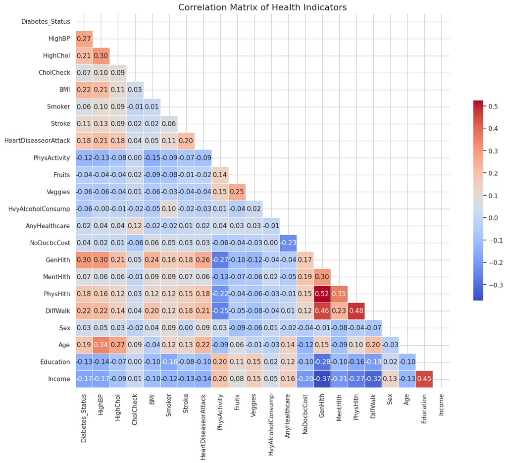

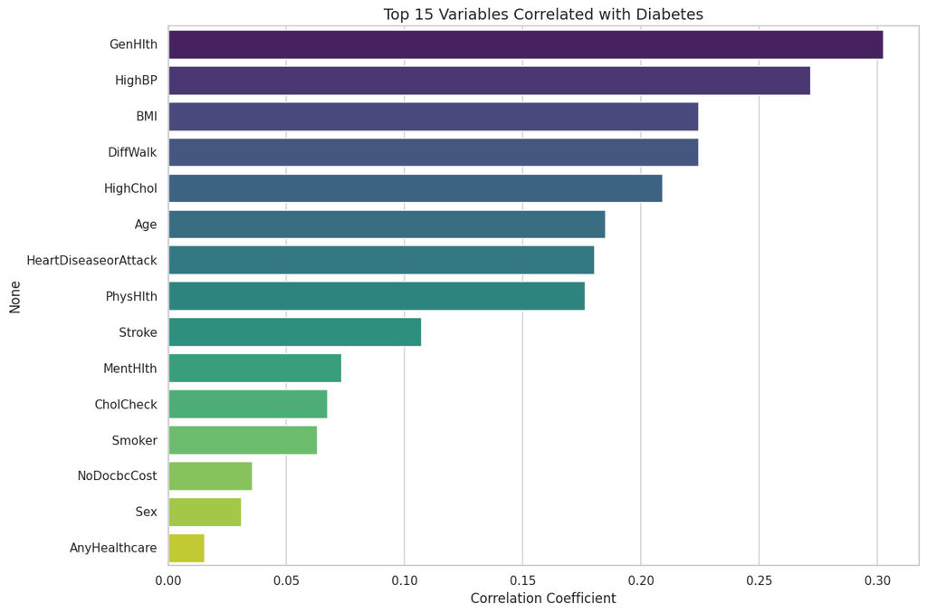

```python
# Correlation analysis using original numeric data
numeric_df = df.select_dtypes(include=['int64', 'float64'])
corr = numeric_df.corr()

# Plot correlation heatmap
plt.figure(figsize=(14, 12))
mask = np.triu(np.ones_like(corr, dtype=bool))
sns.heatmap(corr, mask=mask, annot=True, fmt=".2f", cmap="coolwarm",
           square=True, linewidths=.5, cbar_kws={"shrink": .5})
plt.title('Correlation Matrix of Health Indicators', fontsize=16)
plt.tight_layout()
plt.show()

# Extract and plot top correlations with Diabetes_Stats
diabetes_corr = corr['Diabetes_Status'].sort_values(ascending=False)
plt.figure(figsize=(12, 8))
sns.barplot(x=diabetes_corr.values[1:16], y=diabetes_corr.index[1:16], hue=diabetes_corr
            .index[1:16], palette='viridis', legend=False)
plt.title('Top 15 Variables Correlated with Diabetes', fontsize=14)
plt.xlabel('Correlation Coefficient')
plt.tight_layout()
plt.show()
```

The prevalence of diabetes shows minimal variation between sexes. Both females and males exhibit similar patterns with approximately 13-15% having diabetes and 1-2% having prediabetes. This suggests that biological sex alone may not be a strong independent risk factor for diabetes, though interactions between sex and other risk factors could still be clinically relevant. The comparable rates across sexes indicate that diabetes prevention and management strategies should target both men and women, with perhaps more emphasis on risk factors that transcend sex differences.

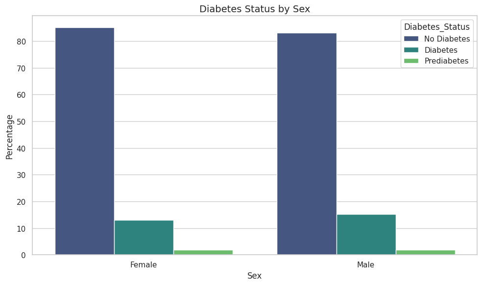

```python
# Sex and Diabetes
plt.figure(figsize=(10, 6))
sex_data = []
for sex in df_clean['Sex'].unique():
    for status in df_clean['Diabetes_Status'].unique():
        subset = df_clean[(df_clean['Sex'] == sex)]
        pct = (subset['Diabetes_Status'] == status).mean() * 100
        sex_data.append({'Sex': sex, 'Diabetes_Status': status, 'Percentage': pct})

sex_df = pd.DataFrame(sex_data)
sns.barplot(x='Sex', y='Percentage', hue='Diabetes_Status', data=sex_df, palette='viridis')
plt.title('Diabetes Status by Sex', fontsize=14)
plt.ylabel('Percentage')
plt.tight_layout()
plt.show()
```

Education level demonstrates a clear inverse relationship with diabetes prevalence. The comparison below shows that individuals with higher education levels (college education) have significantly lower diabetes rates (10% for those with 4+ years of college) compared to those with less education (27% for those who never attended school). Similarly, reveals that higher income levels are associated with lower diabetes prevalence, with rates decreasing from 25% in the lowest income bracket to just 8% in the highest. These socioeconomic gradients highlight the social determinants of health and suggest that educational initiatives and economic policies could indirectly impact diabetes prevalence by addressing these underlying disparities.

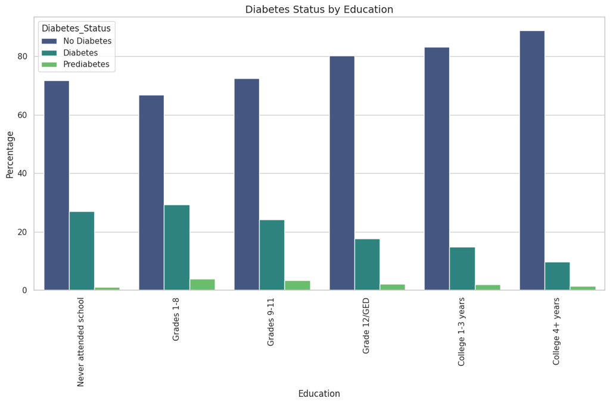

```python
# Education Factors
plt.figure(figsize=(12, 8))
edu_order = [v for k, v in sorted(education_map.items()) if v not in ['No Response']]
edu_data = []
for edu in edu_order:
    if edu in df_clean['Education'].values:
        for status in df_clean['Diabetes_Status'].unique():
            subset = df_clean[(df_clean['Education'] == edu)]
            if len(subset) > 0:
                pct = (subset['Diabetes_Status'] == status).mean() * 100
                edu_data.append({'Education': edu, 'Diabetes_Status': status, 'Percentage': pct})

edu_df = pd.DataFrame(edu_data)
sns.barplot(x='Education', y='Percentage', hue='Diabetes_Status', data=edu_df, palette='viridis')
plt.title('Diabetes Status by Education', fontsize=14)
plt.ylabel('Percentage')
plt.xticks(rotation=90)
plt.tight_layout()
plt.show()
```

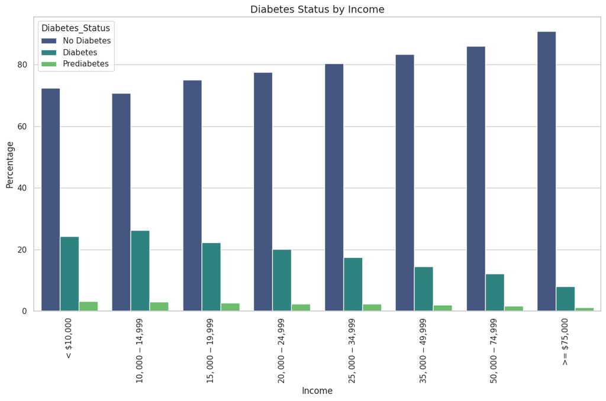

```python
# Income and Diabetes
plt.figure(figsize=(12, 8))
income_order = [v for k, v in sorted(income_map.items()) if v not in ['Not Sure', 'No Response']]
income_data = []
for inc in income_order:
    if inc in df_clean['Income'].values:
        for status in df_clean['Diabetes_Status'].unique():
            subset = df_clean[(df_clean['Income'] == inc)]
            if len(subset) > 0:
                pct = (subset['Diabetes_Status'] == status).mean() * 100
                income_data.append({'Income': inc, 'Diabetes_Status': status, 'Percentage': pct})

income_df = pd.DataFrame(income_data)
sns.barplot(x='Income', y='Percentage', hue='Diabetes_Status', data=income_df, palette='viridis')
plt.title('Diabetes Status by Income', fontsize=14)
plt.ylabel('Percentage')
plt.xticks(rotation=90)
plt.tight_layout()
plt.show()
```

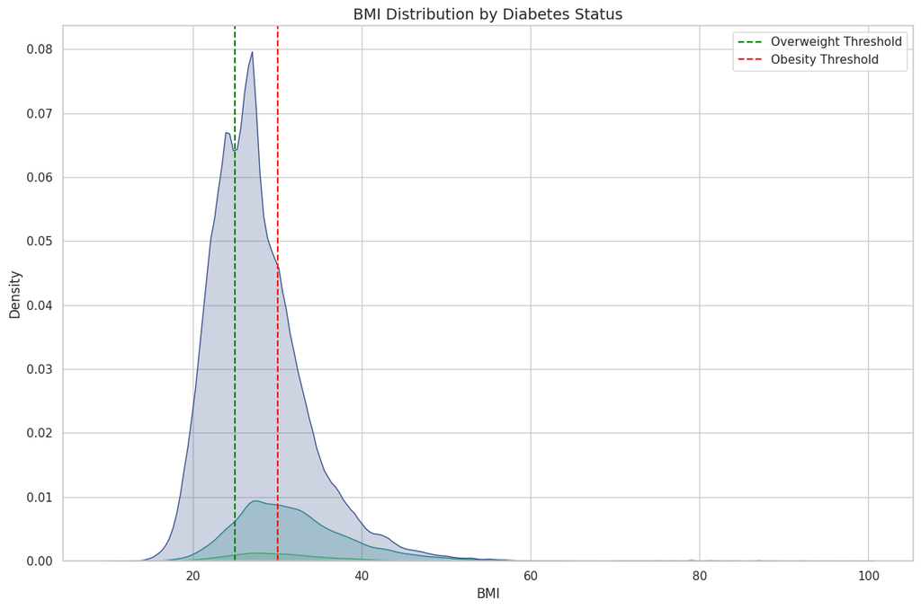

```python
# BMI Distribution by Diabetes Status
plt.figure(figsize=(12, 8))
sns.kdeplot(data=df_clean, x='BMI', hue='Diabetes_Status', palette='viridis', fill=True)
plt.title('BMI Distribution by Diabetes Status', fontsize=14)
plt.xlabel('BMI')
plt.ylabel('Density')
plt.axvline(x=25, color='green', linestyle='--', label='Overweight Threshold')
plt.axvline(x=30, color='red', linestyle='--', label='Obesity Threshold')
plt.legend()
plt.tight_layout()
plt.show()
```

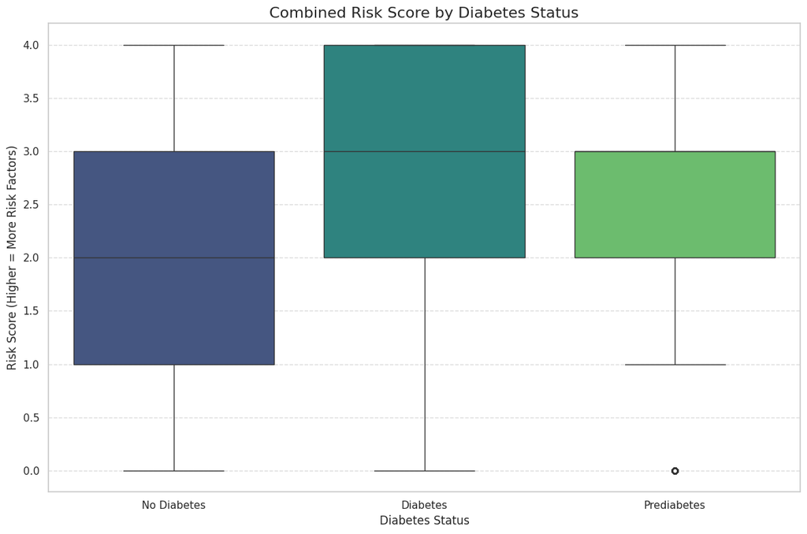

```python
# Risk Factor Analysis
plt.figure(figsize=(12, 8))
risk_df = df.copy()
risk_df['BMI_Risk'] = risk_df['BMI'].apply(lambda x: 0 if x < 25 else (1 if x < 30 else 2))
risk_df['Total_Risk'] = risk_df['HighBP'] + risk_df['HighChol'] + risk_df['BMI_Risk']
risk_df['Diabetes_Status'] = df_clean['Diabetes_Status']

sns.boxplot(x='Diabetes_Status', y='Total_Risk', data=risk_df, palette='viridis')
plt.title('Combined Risk Score by Diabetes Status', fontsize=16)
plt.xlabel('Diabetes Status')
plt.ylabel('Risk Score (Higher = More Risk Factors)')
plt.grid(axis='y', linestyle='--', alpha=0.7)
plt.tight_layout()
plt.show()
```

The scatter plot exploring the relationship between age, BMI, and diabetes status reveals complex interactions between these variables. While higher BMI values are more frequently associated with diabetes regardless of age, the distribution of points suggests that the BMI threshold for diabetes risk may vary across age groups. This visualization helps identify particularly vulnerable populations—those with both advanced age and elevated BMI—who may benefit most from targeted screening and intervention efforts.

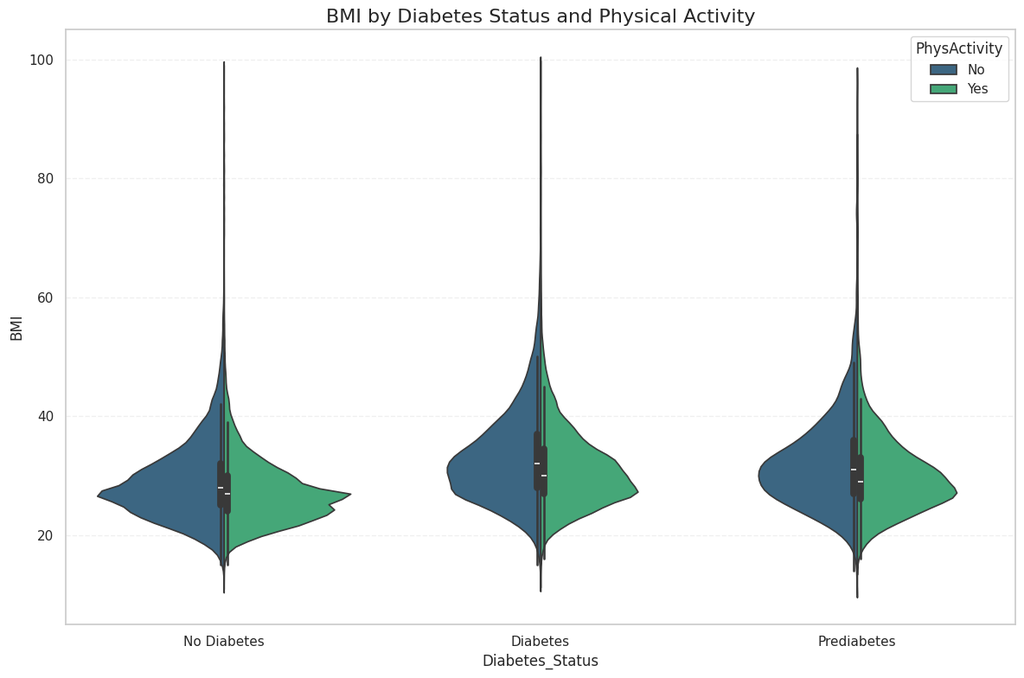

```python
# BMI and Physical Activity Relationship
plt.figure(figsize=(12, 8))
physical_act_data = pd.DataFrame({
    'BMI': df['BMI'],
    'PhysActivity': df_clean['PhysActivity'],
    'Diabetes_Status': df_clean['Diabetes_Status']
})

sns.violinplot(x='Diabetes_Status', y='BMI', hue='PhysActivity',
              data=physical_act_data, palette='viridis', split=True)
plt.title('BMI by Diabetes Status and Physical Activity', fontsize=16)
plt.grid(axis='y', linestyle='--', alpha=0.3)
plt.tight_layout()
plt.show()
```

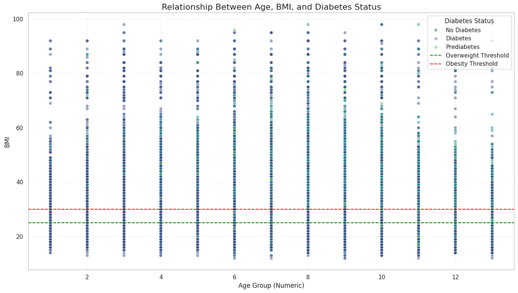

```python
# Age, BMI, and Diabetes Status
plt.figure(figsize=(14, 8))
age_bmi_data = pd.DataFrame({
    'Age_Numeric': df['Age'],
    'BMI': df['BMI'],
    'Diabetes_Status': df_clean['Diabetes_Status']
})

sns.scatterplot(x='Age_Numeric', y='BMI', hue='Diabetes_Status',
               data=age_bmi_data, palette='viridis', alpha=0.5)
plt.title('Relationship Between Age, BMI, and Diabetes Status', fontsize=16)
plt.xlabel('Age Group (Numeric)')
plt.ylabel('BMI')
plt.axhline(y=25, color='green', linestyle='--', label='Overweight Threshold')
plt.axhline(y=30, color='red', linestyle='--', label='Obesity Threshold')
plt.legend(title='Diabetes Status')
plt.grid(True, linestyle='--', alpha=0.3)
plt.tight_layout()
plt.show()
```

# Conclusion

This exploratory data analysis reveals diabetes as a complex condition with multiple interrelated risk factors spanning demographics, lifestyle behaviors, comorbidities, and socioeconomic indicators. The clear patterns observed across BMI distributions, age groups, comorbidity rates, and socioeconomic gradients provide valuable insights for developing targeted prevention strategies and personalized interventions. The analysis particularly highlights the importance of addressing modifiable factors such as physical activity and diet, while recognizing the influence of social determinants like education and income on diabetes risk. These findings can inform both clinical approaches to diabetes management and public health policies aimed at reducing diabetes burden in the population.